# Counterfactual Analysis

These notes follows the code shown in the [Foundations of Program Evaluation](https://ds4ps.org/pe4ps-textbook/docs/index.html) textbook.

# Libraries

```r
library(tidyverse)
library(cowplot)
library(fpp3)
library(Wats)
```

# Interrupted Time Series

## General Concept

Interrupted time series analysis is useful for longitudinal data with the goal of analyzing change with an outcome variable based on some type of intervention. In general, there are four types of effect to analyze:

- No effect
- Immediate but not a sustained effect
- Not immediate but a sustained effect
- Immediate and sustained effect

```r
fake_data <- data.frame(
  time = 0:20,
  ex1 = 1:21,
  ex2 = c(1:11, 2:11),
  ex3 = c(1:11, 11, 11, 9, 11, 9:4),
  ex4 = c(1:11, 8,8,8:1),
  treatment = c(rep("a", 11), rep("b", 10))
)
```

For instance the plot below shows an intervention that had no effect on the variable of interest

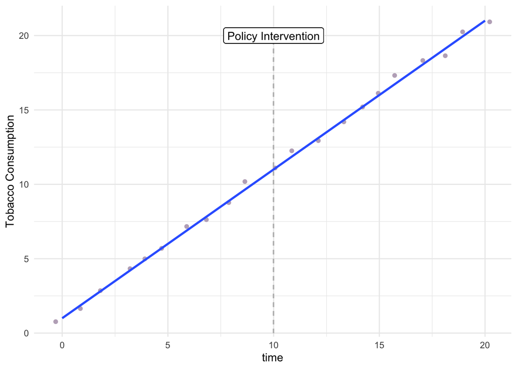

```r
fake_data %>%
  select(time, ex1) %>%
  ggplot(aes(x = time, y = ex1)) +
  geom_jitter(colour = "#BEAFC2") +
  ylab(label = "Tobacco Consumption") +
  geom_smooth(formula = y ~ x,
    method = "lm",
    se = FALSE) +
  geom_segment(
    x = 10,
    xend = 10,
    y = 0,
    yend = 20,
    linetype = 2,
    color = "grey"
  ) +
  geom_label(
    label = "Policy Intervention",
    x = 10,
    y = 20
  ) +
  theme_minimal()
```

This plot is an example of an intervention that has an immediate but not a sustained effect

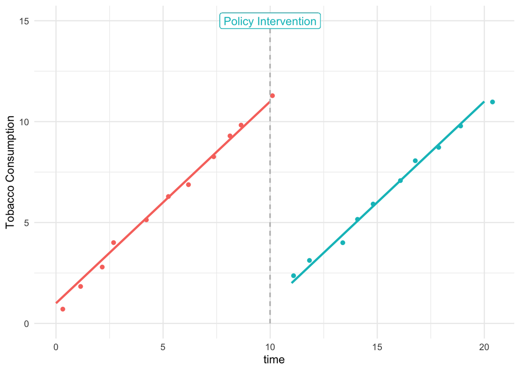

```r
fake_data %>%
  select(-ex1) %>%
  ggplot(aes(x = time, y = ex2, color = treatment)) +
  geom_jitter() +
  ylab(label = "Tobacco Consumption") +
   geom_smooth(formula = y ~ x,
     method = lm,
     se = FALSE)+
  ylim(c(0, 15)) +
  geom_segment(
    x = 10,
    xend = 10,
    y = 0,
    yend = 15,
    linetype = 2,
    color = "grey"
  ) +
  geom_label(
    label = "Policy Intervention",
    x = 10,
    y = 15
  ) +
  theme_minimal() +
  theme(legend.position = "none")
```

This plot has no immediate effect, but a sustained long-term effect

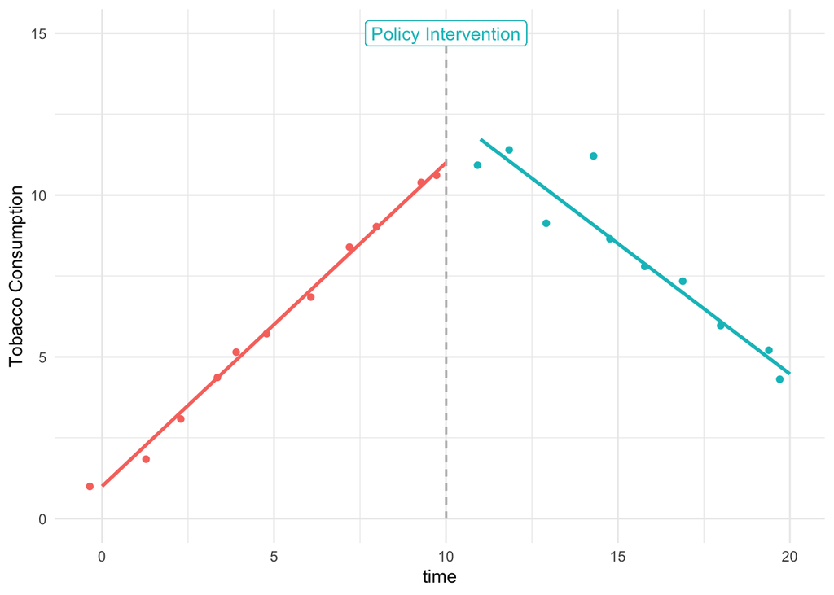

```r
fake_data %>%
  select(-c(ex1, ex2)) %>%
  ggplot(aes(x = time, y = ex3, color = treatment)) +
  geom_jitter() +
  ylab(label = "Tobacco Consumption") +
   geom_smooth(formula = y ~ x,
     method = lm,
     se = FALSE)+
  ylim(c(0, 15)) +
  geom_segment(
    x = 10,
    xend = 10,
    y = 0,
    yend = 15,
    linetype = 2,
    color = "grey"
  ) +
  geom_label(
    label = "Policy Intervention",
    x = 10,
    y = 15
  ) +
  theme_minimal() +
  theme(legend.position = "none")
```

This final plot shows an immediate and sustained effect.

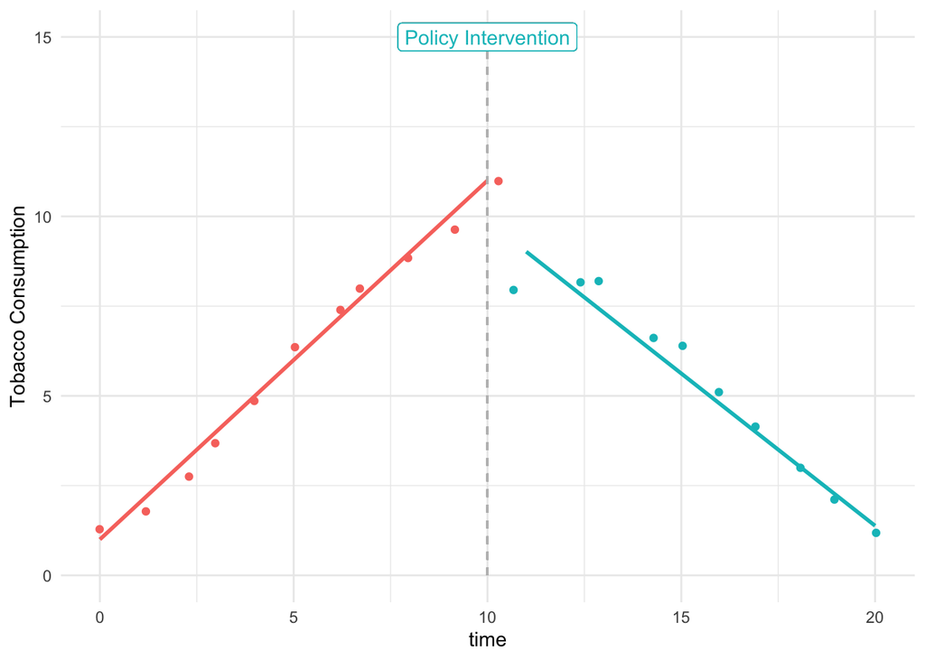

```r
fake_data %>%
  select(-c(ex1, ex2, ex3)) %>%
  ggplot(aes(x = time, y = ex4, color = treatment)) +
  geom_jitter() +
  ylab(label = "Tobacco Consumption") +
   geom_smooth(formula = y ~ x,
     method = lm,
     se = FALSE)+
  ylim(c(0, 15)) +
  geom_segment(
    x = 10,
    xend = 10,
    y = 0,
    yend = 15,
    linetype = 2,
    color = "grey"
  ) +
  geom_label(
    label = "Policy Intervention",
    x = 10,
    y = 15
  ) +
  theme_minimal() +
  theme(legend.position = "none")
```

## Statistical Model

The general mathematical model is

$$Y = b_0 + b_1T + b_2D + b_3P+ e$$

Where:

$Y$ is the outcome variable

$T$ is a continuous variable representing time

$D$ is a dummy variable where 0 is a collection before the intervention and 1 is a collection after the intervention

$P$ is a continuous variable representing time passed since the intervention occured

$b_0$ is the baseline average of the outcome variable

$b_1$ is the pre-intervention slope

$b_2$ is the magnitude of the immediate effect

$b_3$ is the post-intervention slope

$e$ is an error term to account for noise in the data

## Counterfactual

The basic concept of the counterfactual is to examine what would happen to the trend had the intervention not occured vice the current trend after enactment of the intervention.

Hence, the base equation for the non-intervention reduces to:

$$\hat{Y} = b_0 + b_1T + e$$
Thus, for any time period after the implementation of the intervention you are calculating the residual of $Y - \hat{Y}$ which represents a measure of the impact of the intervention. To put it another way
$$Y - \hat{Y} = b_2D + b_3P$$

## Example

### Data

The dataset contains 365 daily observations of the wellbeing of a class of students. Wellbeing is measured by a index from 0 to 300. At t = 201 students will start attend a mental health education class. We want to understand how (and if) their wellbeing improves.

```r
URL <- "https://github.com/DS4PS/pe4ps-textbook/blob/master/data/time-series-example.rds?raw=true"
dataTS <- readRDS(gzcon(url( URL )))
dplyr::glimpse(dataTS)
```

```
## Rows: 365
## Columns: 4
## $ Y <dbl> 38.50479, 48.61841, 102.44811, 58.05859, 60.03438, 107.77661, 70.401…
## $ T <dbl> 1, 2, 3, 4, 5, 6, 7, 8, 9, 10, 11, 12, 13, 14, 15, 16, 17, 18, 19, 2…
## $ D <dbl> 0, 0, 0, 0, 0, 0, 0, 0, 0, 0, 0, 0, 0, 0, 0, 0, 0, 0, 0, 0, 0, 0, 0,…
## $ P <dbl> 0, 0, 0, 0, 0, 0, 0, 0, 0, 0, 0, 0, 0, 0, 0, 0, 0, 0, 0, 0, 0, 0, 0,…
```

### Plot of Data

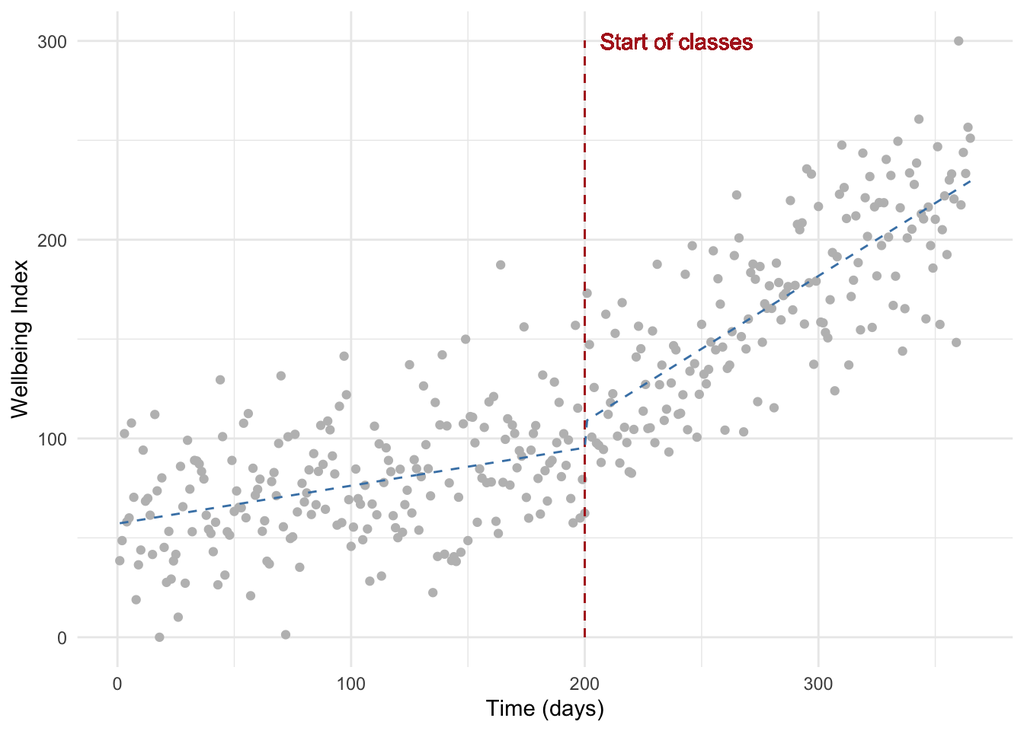

```r
ts_reg <- lm(Y ~ T + D + P, data = dataTS)

dataTS %>%
  ggplot(aes(x = T, y = Y)) +
  geom_point(color = "grey") +
  xlab(label = "Time (days)") +
  ylab(label = "Wellbeing Index") +
  geom_segment(
    x = 200,
    xend = 200,
    y = 0,
    yend = 300,
    linetype = 2,
    color = "firebrick"
  ) +
  geom_text(
    label = "Start of classes",
    x = 200,
    y = 300,
    hjust = -0.1,
    color = "firebrick"
  ) +
  geom_line(aes(T, ts_reg$fitted.values), color = "steelblue", lty = 2) +
  theme_minimal()
```

### View the model

```r
model_stats <- broom::tidy(ts_reg)
model_stats$term <- c("Constant", "Time", "Treatment", "Time Since Treatment")
model_stats
```

| term | estimate | std.error | statistic | p.value |
| --- | --- | --- | --- | --- |
| Constant | 57.1530582 | 4.12694684 | 13.848751 | 2.810390e-35 |
| Time | 0.1909886 | 0.03560691 | 5.363807 | 1.458690e-07 |
| Treatment | 13.0915499 | 6.12009429 | 2.139109 | 3.309720e-02 |
| Time Since Treatment | 0.5423239 | 0.05937835 | 9.133360 | 4.838723e-18 |

A review of the model statistics show that the average increased at a rate of 0.19 points per day before the attending the class. Immediately following the class, the average well being increased by 13 points followed by a sustained average increase of 0.54 points per day.

### Counterfactual Plot

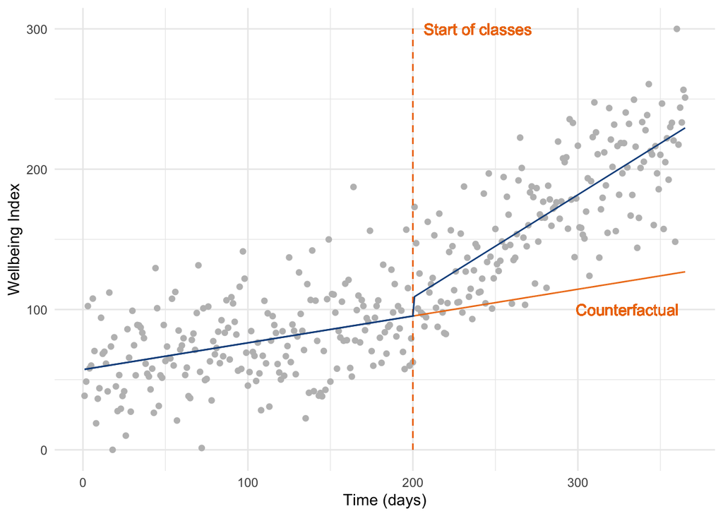

```r
pred <- predict(ts_reg, dataTS)
datanew <- as.data.frame(cbind(T = rep(1 : 365), D = rep(0), P = rep(0)))
pred_cf <- predict(ts_reg, datanew)
cf_color <- c(rep("dodgerblue4", 200), rep("darkorange2", 165))

dataTS %>%
  ggplot(aes(x = T, y = Y)) +
  geom_point(color = "grey") +
  xlab(label = "Time (days)") +
  ylab(label = "Wellbeing Index") +
  geom_segment(
    x = 200,
    xend = 200,
    y = 0,
    yend = 300,
    linetype = 2,
    color = "darkorange2"
  ) +
  geom_text(
    label = "Start of classes",
    x = 200,
    y = 300,
    hjust = -0.1,
    color = "darkorange2"
  ) +
  geom_line(aes(T, pred), color = "dodgerblue4") +
  geom_line(aes(T, pred_cf), color = cf_color) +
    geom_text(
    label = "Counterfactual",
    x = 330,
    y = 100,
    color = "darkorange2"
  ) +
  theme_minimal()
```

## Oklahoma City Bombing Study

This analysis replicates a study conducted by Rogers, John, and Coleman (2005). In essence, there is a theory that birth rates tend to change in relation to sociocultural situations such as major disasters. ndividuals feel more prone to have children as a response to major life losses or because they feel closer to traditional values (such as having a family) when unexpected events occur. By contrast, they might be less willing to have children when experiencing events that negatively affect their life style.

### Data

The data has over 1,400 observations with a total of 12 variables. You can find the details by typing the command `?CountyMonthBirthRate2014Version`.

```r
data(CountyMonthBirthRate2014Version)
okc_data <- CountyMonthBirthRate2014Version %>%
  filter(CountyName == "oklahoma")
rm(CountyMonthBirthRate2014Version)
dplyr::glimpse(okc_data)
```

```
## Rows: 120
## Columns: 12
## $ Fips             <int> 40109, 40109, 40109, 40109, 40109, 40109, 40109, 4010…
## $ CountyName       <chr> "oklahoma", "oklahoma", "oklahoma", "oklahoma", "okla…
## $ Year             <int> 1990, 1990, 1990, 1990, 1990, 1990, 1990, 1990, 1990,…
## $ Month            <int> 1, 2, 3, 4, 5, 6, 7, 8, 9, 10, 11, 12, 1, 2, 3, 4, 5,…
## $ FecundPopulation <dbl> 143192.0, 143278.7, 143365.3, 143452.0, 143538.7, 143…
## $ BirthCount       <int> 853, 758, 886, 871, 822, 834, 856, 861, 844, 880, 813…
## $ Date             <date> 1990-01-15, 1990-02-15, 1990-03-15, 1990-04-15, 1990…
## $ DaysInMonth      <int> 31, 28, 31, 30, 31, 30, 31, 31, 30, 31, 30, 31, 31, 2…
## $ DaysInYear       <int> 365, 365, 365, 365, 365, 365, 365, 365, 365, 365, 365…
## $ StageID          <int> 1, 1, 1, 1, 1, 1, 1, 1, 1, 1, 1, 1, 1, 1, 1, 1, 1, 1,…
## $ BirthRateMonthly <dbl> 5.957037, 5.290390, 6.180016, 6.071717, 5.726680, 5.8…
## $ BirthRate        <dbl> 70.13930, 68.96401, 72.76470, 73.87256, 67.42704, 70.…
```

### Plot of Data

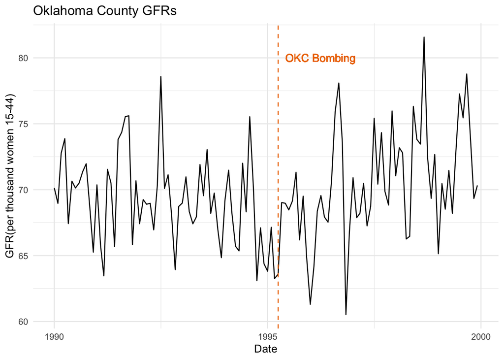

```r
okc_birth_rate <- okc_data %>%
  mutate(Month = yearmonth(Date)) %>%
  group_by(Month) %>%
  summarise(monthly_average = mean(BirthRate)) %>%
  as_tsibble(index = Month)

okc_birth_rate %>%
  ggplot(aes(x = as.Date(Month), y = monthly_average)) +
  geom_line() +
  labs(x = "Date",
       y = "GFR(per thousand women 15-44)",
       title = "Oklahoma County GFRs") +
  geom_vline(xintercept = as.Date(okc_birth_rate$Month[64]), lty = 2, color="darkorange2") +
  geom_text(
    label = "OKC Bombing",
    x = as.Date(okc_birth_rate$Month[64]),
    y = 80,
    hjust = -0.1,
    color = "darkorange2"
  ) +
  theme_minimal()
```

### Create New Features

```r
# Create a time variable from 1 to last row of the dataset
okc_data$time <- rep( 1 : nrow( okc_data))

# Create a dummy variable equal to 1 if after 1995 or after May 1995, and equal to 0 otherwise
okc_data$treatment <- ifelse( okc_data$Year > 1995 | okc_data$Year == 1995 & okc_data$Month >= 5, 1, 0)

# Time since event occured
okc_data$time_after_event <- ifelse(okc_data$time <= 64, 0, okc_data$time - 64)
# If we look at the frequency of the treatment variable, we see that 64 rows has received no treatment and 56 rows did receive the treatment.
table(okc_data$treatment)
```

```
##
##  0  1
## 64 56
```

### Regression Model

```r
okc_model <- lm(
  BirthRateMonthly ~
    time +
    treatment +
    time_after_event,
  data = okc_data
)

okc_model_stats <- broom::tidy(okc_model)
okc_model_stats$term <- c("Constant", "Time", "Treatment", "Time Since Treatment")
okc_model_stats
```

| term | estimate | std.error | statistic | p.value |
| --- | --- | --- | --- | --- |
| Constant | 5.923856738 | 0.084962437 | 69.7232445 | 1.536646e-96 |
| Time | -0.005187809 | 0.002272747 | -2.2826162 | 2.427508e-02 |
| Treatment | 0.053721157 | 0.123149439 | 0.4362274 | 6.634826e-01 |
| Time Since Treatment | 0.013649589 | 0.003588366 | 3.8038449 | 2.289236e-04 |

#### 1. What was the trend of the birth rate before the event?

The model shows a slight downward monthly trend in the birth rate before the bombing. While it is rather small, it is statistically significantly different from zero.

#### 2. What was the change in the birth rate immediatedly after the event?

The birth rate did not change significantly from zero, thus there was not likely an immediate effect.

#### 3. What is the trend of the birth rate after the event?

The model shows an upward monthly trend in the birth rate after the bombing that was almost three times the magnitude from the birth rate before the bombing. Specifically, the absolute difference, in aggregate, was approximately 0.009 births per month. This factor is statistically significantly different from zero which suggests a long-term sustaining effect.

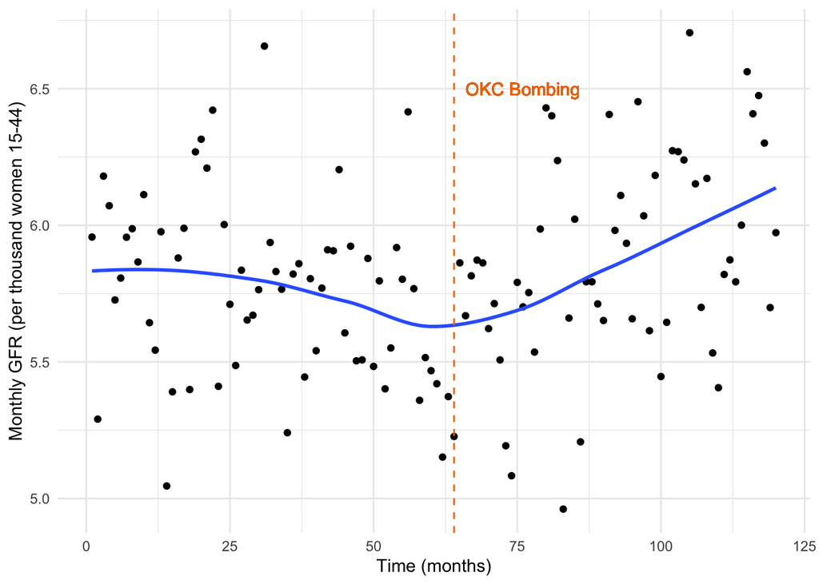

```r
okc_data %>%
  ggplot(aes(x = time, y = BirthRateMonthly)) +
  geom_point() +
  labs(
    x = "Time (months)",
    y = "Monthly GFR (per thousand women 15-44)"
  ) +
  geom_smooth(formula = y ~ x,
              method = "loess",
              se = FALSE) +
  geom_vline(xintercept = 64,
             lty = 2,
             color = "darkorange2") +
  geom_text(
    label = "OKC Bombing",
    x = 64,
    y = 6.5,
    hjust = -0.1,
    color = "darkorange2"
  ) +
  theme_minimal()
```

### Reaximination of the effect after event

The previous analysis showed there was not an immediate effect after the bombing. The authors origninally hypothesized this could be due to the time it takes for a pregnancy to complete its full gestation period.

```r
# Our new treatment variable is equal to 1 if the bombing has occured and 9 months have passed.It is equal to zero otherwise.
okc_data$treatment2 <- ifelse( okc_data$Year > 1996 | okc_data$Year == 1996 & okc_data$Month >= 2, 1, 0)

# Our Time Since Treatment variable starts 9 months after the bombing, instead than at the time of the bombing.
okc_data$new_time_after_event <- ifelse(okc_data$time <= 73, 0, okc_data$time - 73)

#New regression model
okc_model2 <- lm(
  BirthRateMonthly ~
    time +
    treatment2 +
    new_time_after_event,
  data = okc_data
)

okc_model2_stats <- broom::tidy(okc_model2)
okc_model2_stats$term <- c("Constant", "Time", "Treatment", "Time Since Treatment")
okc_model2_stats
```

| term | estimate | std.error | statistic | p.value |
| --- | --- | --- | --- | --- |
| Constant | 5.904251645 | 0.079354252 | 74.4037213 | 9.647706e-100 |
| Time | -0.004278817 | 0.001863680 | -2.2958971 | 2.347782e-02 |
| Treatment | 0.125663567 | 0.126241688 | 0.9954205 | 3.216037e-01 |
| Time Since Treatment | 0.012978965 | 0.004060906 | 3.1960763 | 1.795073e-03 |